# NHSStepUpReport

2025-03-05

# Part One

**1** *Create two vertical bar charts for comparison. First, create a bar chart showing the total annual antidepressant prescribing (items). Second, create a bar chart that shows the total antidepressant prescribing cost. Describe the trend of each chart and compare the charts against each other.*

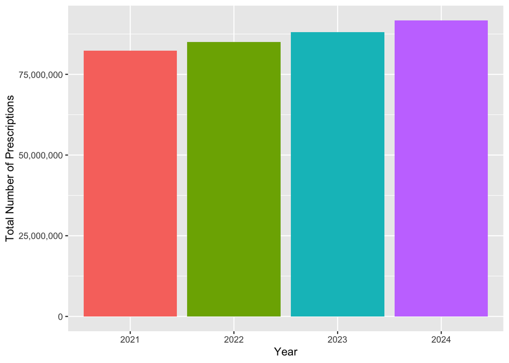

```r
b1 <- df %>%
  group_by(YEAR) %>%
  summarise(totalCOUNT = sum(ITEMS)) %>%
  ungroup() %>%
  ggplot(aes(x = YEAR, y = totalCOUNT, fill = YEAR)) +
  geom_bar(stat = "identity") +
  labs(x = 'Year',
       y = 'Total Number of Prescriptions') +
  scale_y_continuous(labels = label_comma()) +
  theme(legend.position = 'none')

b2 <- df %>%
  group_by(YEAR) %>%
  summarise(totalCOST = sum(COST)) %>%
  ungroup() %>%
  ggplot(aes(x = YEAR, y = totalCOST, fill = YEAR)) +
  geom_bar(stat = "identity") +
  labs(x = 'Year', y = 'Total Cost of Prescriptions') +
  scale_y_continuous(labels = label_comma()) +
  theme(legend.position = 'none')

b1
```

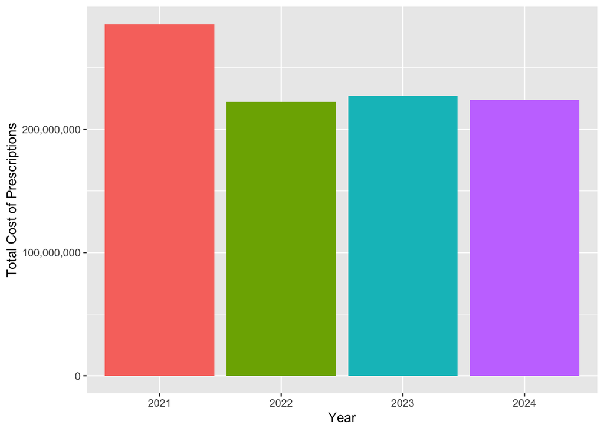

```r
b2
```

**2** *Create two tables for comparison. First, create a table showing the total annual antidepressant prescribing per region (items, pivot_wider). Second, create a table showing the annual antidepressant prescribing cost per region (pivot_wider). Describe some regional changes and contrasts between 2021 and 2024. (NOTE: within mutate a numerical column name, e.g. 2021 must be placed with ticks, so 2021, for example mutate(NEW_VAL = 2021 + 2022))*

```r
t1 <- df %>%
  group_by(REGION, YEAR) %>%
  summarise(totalCount = sum(ITEMS)) %>%
  ungroup() %>%
  pivot_wider(names_from = REGION, values_from = totalCount)
t1
```

```
## # A tibble: 4 × 8
##   YEAR  `EAST OF ENGLAND`  LONDON MIDLANDS NORTH EAST AND YORKSHI…¹ `NORTH WEST`
##   <fct>             <int>   <int>    <int>                    <int>        <int>
## 1 2021           10088696 7529806 15521842                 16467536     12630435
## 2 2022           10386159 7900817 16270811                 16920234     13023335
## 3 2023           10715976 8278150 17071488                 17461136     13448199
## 4 2024           11082180 8852394 17776322                 18311514     13950677
## # ℹ abbreviated name: ¹`NORTH EAST AND YORKSHIRE`
## # ℹ 2 more variables: `SOUTH EAST` <int>, `SOUTH WEST` <int>
```

```r
t2 <- df %>%
  group_by(REGION, YEAR) %>%
  summarise(totalCost = sum(COST)) %>%
  ungroup() %>%
  pivot_wider(names_from = REGION, values_from = totalCost)
t2
```

```
## # A tibble: 4 × 8
##   YEAR  `EAST OF ENGLAND`    LONDON MIDLANDS NORTH EAST AND YORKS…¹ `NORTH WEST`
##   <fct>             <dbl>     <dbl>    <dbl>                  <dbl>        <dbl>
## 1 2021          33887748. 27626450.   5.40e7              49257077.    42451998.
## 2 2022          26732981. 21718574.   4.23e7              37685770.    31943711.
## 3 2023          27274464. 22308597.   4.41e7              38568941.    32446429.
## 4 2024          27162002. 22428439.   4.37e7              37507208.    31768651.
## # ℹ abbreviated name: ¹`NORTH EAST AND YORKSHIRE`
## # ℹ 2 more variables: `SOUTH EAST` <dbl>, `SOUTH WEST` <dbl>
```

Summary:

From 2021 to 2024, overall costs have significantly decreased nationally - likely with 2021 as an outlier from COVID. Total prescriptions have gone up steadily since 2021 across all regions, with some increasing more tan others i.e NE and Yorkshire. Total costs from 2023 > 2024 have decreased in most regions, but increased in London.

**3** *By now you may have noticed there are contrasts between antidepressant prescribing volumes and costs. Next, we will create two horizontal bar charts for comparison. First, create an ordered bar chart showing the 10 most prescribed antidepressants in the most recent year (items). Second, create an ordered bar chart that shows antidepressants with the greatest total prescribing cost in the most recent year. Highlight and describe any differences between the charts.*

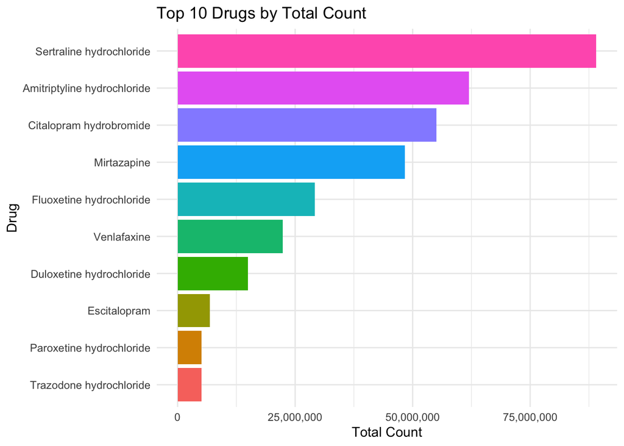

```r
b3_count <- df %>%
  group_by(DRUG) %>%
  summarise(totalCount = sum(ITEMS)) %>%
  ungroup() %>%
  top_n(10, totalCount) %>%
  mutate(DRUG = fct_reorder(DRUG, totalCount)) %>%
  ggplot(aes(x = DRUG, y = totalCount, fill = DRUG)) +
  geom_col() +
  scale_y_continuous(labels = label_comma()) +
  coord_flip() +
  theme_minimal() +
  labs(title = "Top 10 Drugs by Total Count",
       x = "Drug",
       y = "Total Count") +
  theme(legend.position = 'none')

b3_cost <- df %>%
  group_by(DRUG) %>%
  summarise(totalCost = sum(COST)) %>%
  ungroup() %>%
  top_n(10, totalCost) %>%
  mutate(DRUG = fct_reorder(DRUG, totalCost)) %>%
  ggplot(aes(x = DRUG, y = totalCost, fill = DRUG)) +
  geom_col() +
  scale_y_continuous(labels = label_comma()) +
  coord_flip() +
  theme_minimal() +
  labs(title = "Top 10 Drugs by Total Cost",
       x = "Drug",
       y = "Total Cost") +
  theme(legend.position = 'none') +
  theme_economist(base_size = 7) +
  theme(legend.position = 'none')

b3_count
```

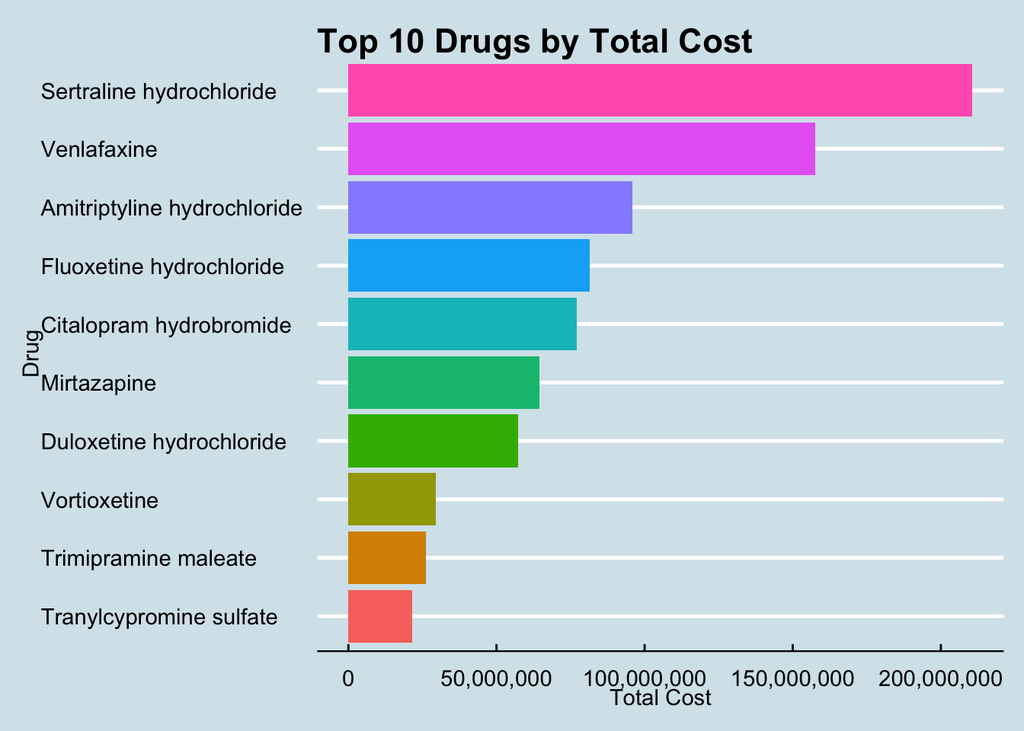

```r
b3_cost
```

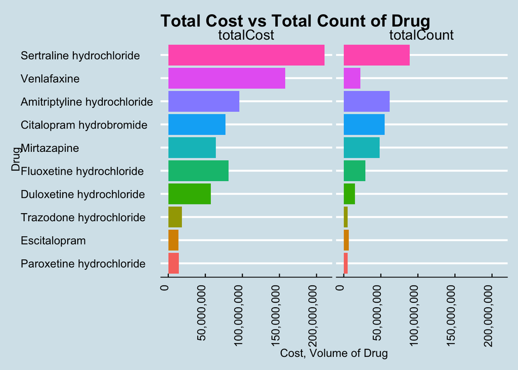

```r
df_combined <- df %>%
  group_by(DRUG) %>%
  summarise(totalCount = sum(ITEMS),
            totalCost = sum(COST)) %>%
  ungroup() %>%
  top_n(10, totalCount) %>%
  pivot_longer(cols = c(totalCount, totalCost), names_to = "CostOrCount", values_to = "values") %>%
  mutate(DRUG = fct_reorder(DRUG, values))

b_facet <- df_combined %>%
  ggplot(aes(x = DRUG, y = values, fill = DRUG)) +
  geom_col() +
  coord_flip() +
  facet_wrap(~CostOrCount, scales = "fixed") +
  scale_y_continuous(labels = label_comma()) +
  labs(x = 'Drug',
        y = "Cost, Volume of Drug",
        title = 'Total Cost vs Total Count of Drug') +
  theme_economist(base_size = 7) +
  theme(axis.text.x = element_text(angle = 90, hjust = 1)) +
  theme(legend.position = 'none')

b_facet
```

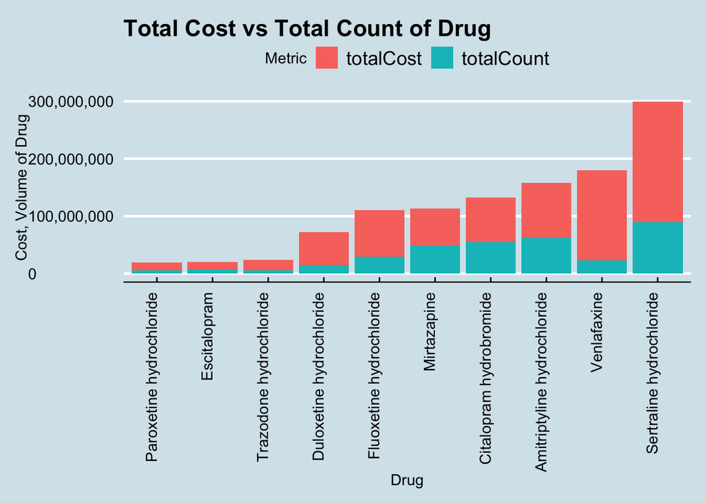

```r
cbar <- df_combined %>%
  ggplot(aes(x = DRUG, y = values, fill = CostOrCount)) +
  geom_col() +
  scale_y_continuous(labels = label_comma()) +
  theme_economist(base_size = 7) +
  theme(axis.text.x = element_text(angle = 90, hjust = 1)) +
  labs(x = 'Drug',
        y = "Cost, Volume of Drug",
        title = 'Total Cost vs Total Count of Drug',
       fill = "Metric")

cbar
```

# Part Two

*Now you have a good understanding around national and regional antidepressant prescribing volume and cost trends. You will be given various topics or points to explore, and you will decide what approach or charts best does this. To supplement the initial analysis, you will now:*

**Look at the longitudinal (monthly) trend for all antidepressant items and for the cost of antidepressant prescribing**

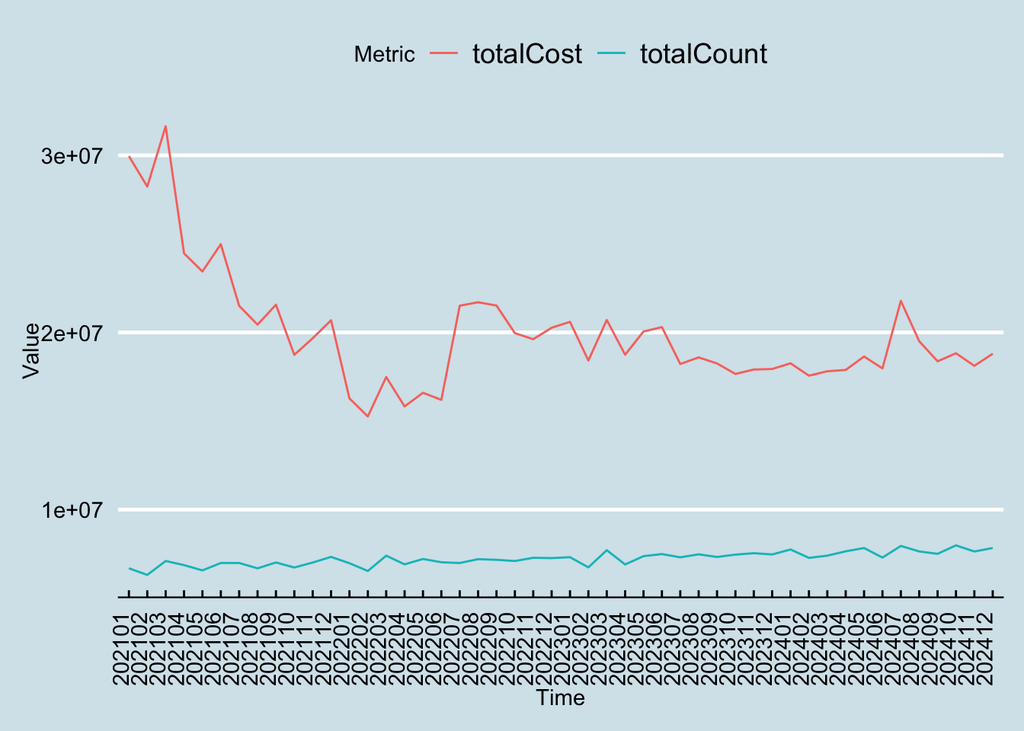

```r
p2df <- df %>%
  group_by(YM) %>%
  summarise(totalCost = sum(COST),
            totalCount = sum(ITEMS)) %>%
  ungroup() %>%
  pivot_longer(cols = c(totalCost, totalCount), names_to = "Metric", values_to = "Value")

p2df %>%
  ggplot() +
  geom_line(aes(x = YM, y = Value, colour = Metric, group = Metric)) +
  theme_economist(
    base_size = 7) +
  theme(axis.text.x = element_text(angle = 90, hjust = 1)) +
  labs (x = 'Time')
```

**Then, explore the data and find the antidepressant drugs that are driving these monthly item and cost trends.**

```r
m1 <- df %>%
  group_by(DRUG, YM) %>%
  summarise(DrugCost = sum(COST)) %>%
  ungroup() %>%
  group_by(YM) %>%
  top_n(10, DrugCost) %>%
  ungroup() %>%
  mutate(YM = as.numeric(YM),
         StartDate = StartDate <- as.Date("2021-01-01"),
         YearCount = YearCount <- StartDate + months(YM))
```

```
## label_key: DRUG
```

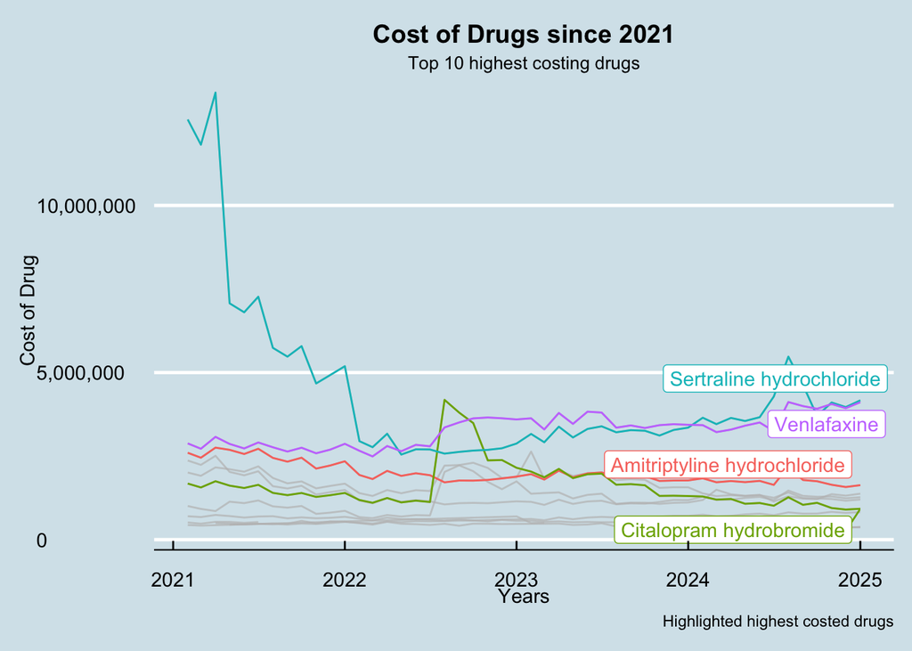

```r
m1 %>%
  ggplot() +
  geom_line(aes(YearCount, DrugCost, color = DRUG, group = DRUG)) +
  gghighlight(max(DrugCost) > 2750000, use_direct_label = TRUE) +
  scale_y_continuous(labels = label_comma()) +
  labs(y = "Cost of Drug",
       x = 'Years',
       title = 'Cost of Drugs since 2021',
       subtitle = 'Top 10 highest costing drugs',
       caption = 'Highlighted highest costed drugs') +
  theme_economist() +
  theme(plot.title = element_text(hjust = 0.5, size = 14, margin = margin(b = 5))) +
  theme(plot.subtitle = element_text(hjust = 0.5, size = 10))
```

```r
m2 <- df %>%
  group_by(DRUG, YM) %>%
  summarise(Costs = sum(COST),
            Totals = sum(ITEMS)) %>%
  ungroup() %>%
  group_by(YM) %>%
  pivot_longer(cols = c(Costs, Totals), names_to = "Metric", values_to = "Value") %>%
  ungroup() %>%
  mutate(YM = as.numeric(YM),
         StartDate = StartDate <- as.Date("2021-01-01"),
         YearCount = YearCount <- StartDate + months(YM)) %>%
  group_by(DRUG, YM) %>%
  top_n(3, Value)
```

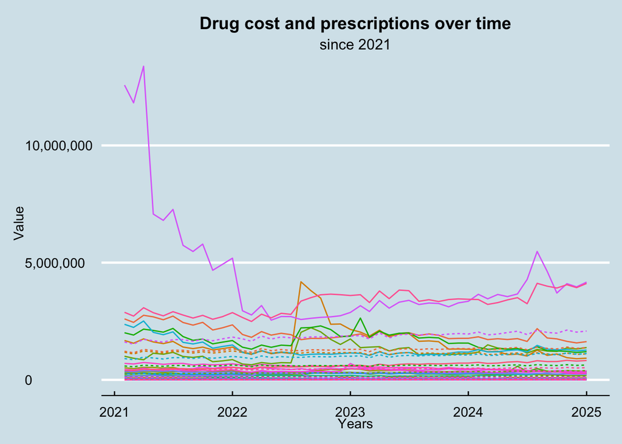

```r
m2 %>% ggplot() +
  geom_line(aes(x = YearCount, y = Value, color = DRUG, group = interaction(DRUG, Metric), linetype = Metric)) +
  scale_y_continuous(labels = label_comma()) +
  theme_economist(base_size = 7) +
  theme(legend.position = 'none') +
  labs(x = 'Years',
       title = 'Drug cost and prescriptions over time',
       subtitle = 'since 2021') +
  theme(plot.title = element_text(hjust = 0.5, size = 14, margin = margin(b = 5))) +
  theme(plot.subtitle = element_text(hjust = 0.5, size = 12))
```

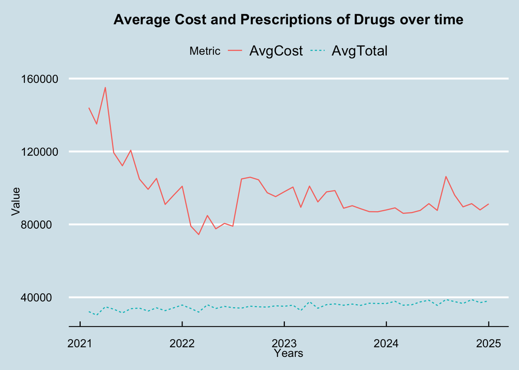

```r
m4 <- df %>%
  group_by(YM) %>%
  summarise(AvgCost = mean(COST),
            AvgTotal = mean(ITEMS)) %>%
  ungroup() %>%
  group_by(YM) %>%
  pivot_longer(cols = c(AvgCost, AvgTotal), names_to = "Metric", values_to = "Value") %>%
  ungroup() %>%
  mutate(YM = as.numeric(YM),
         StartDate = StartDate <- as.Date("2021-01-01"),
         YearCount = YearCount <- StartDate + months(YM))

m4 %>% ggplot() +
  geom_line(aes(x = YearCount, y = Value, linetype = Metric, color = Metric)) +
  theme_economist() +
  labs(title = 'Average Cost and Prescriptions of Drugs over time',
       x = 'Years',) +
  theme(plot.title = element_text(hjust = 0.5, size = 14, margin = margin(b = 10)))
```

**Then give a high-level summary to your work and findings.**

**Part Two Extension (Antidepressant Case studies)**

Focus one one or more antidepressants that play a significant role in national volume and cost trends. Sertraline hydrochloride, citalopram hyrdrobromide, Venlafaxine

Try to offer more granular insight into their effect on national prescribing trends Percentage of total antidepressant volume or cost from a drug

[figure not shown]

```r
prop1 <- df %>%
  mutate(YM = as.numeric(YM),
         StartDate = StartDate <- as.Date("2021-01-01"),
         YearCount = YearCount <- StartDate + months(YM)) %>%
  group_by(YearCount) %>%
  mutate(SertCount = sum(ITEMS[DRUG == "Sertraline hydrochloride"]),
         VenCount = sum(ITEMS[DRUG == "Venlafaxine"]),
         CetaCount = sum(ITEMS[DRUG == "citalopram hyrdrobromide"]),
         TotalItems = sum(ITEMS),
         SertProp = SertCount / TotalItems,
         VenProp = VenCount / TotalItems,
         CetaProp = CetaCount / TotalItems) %>%
  pivot_longer(cols = c(SertProp, VenProp, CetaProp), names_to = "Drug", values_to = "Proportion")

prop1 %>% ggplot() +
  geom_line(aes(x = YearCount, y = Proportion, color = Drug)) +
  scale_y_continuous(labels = label_percent()) +
  labs(x = 'Years',
       y = 'Proporiton of Total Items Prescribed',
       title = 'Proprotion of Total Annual Prescriptions from selected drugs',
       caption = 'Selected Drugs') +
  scale_colour_discrete(labels = c("SertProp" = "Sertraline", "CetaProp" = "Citalopram", "VenProp" = "Venlafaxine")) +
  theme_economist() +
  theme(plot.title = element_text(hjust = 0.5, size = 14, margin = margin(b = 10)))
```

```
## label_key: Drug
```

[figure not shown]

```r
prop2 <- df %>%
  mutate(YM = as.numeric(YM),
         StartDate = StartDate <- as.Date("2021-01-01"),
         YearCount = YearCount <- StartDate + months(YM)) %>%
  group_by(YearCount) %>%
  mutate(SertCount = sum(ITEMS[DRUG == "Sertraline hydrochloride"]),
         VenCount = sum(ITEMS[DRUG == "Venlafaxine"]),
         CetaCount = sum(ITEMS[DRUG == "citalopram hyrdrobromide"]),
         SertCost = sum(COST[DRUG == "Sertraline hydrochloride"]),
         VenCost = sum(COST[DRUG == "Venlafaxine"]),
         CetaCost = sum(COST[DRUG == "citalopram hyrdrobromide"]),
         TotalItems = sum(ITEMS),
         TotalCost = sum(COST),
         SertProp = SertCount / TotalItems,
         VenProp = VenCount / TotalItems,
         CetaProp = CetaCount / TotalItems,
         SertCostProp = SertCost / TotalCost,
         VenCostProp = VenCost / TotalCost,
         CetaCostProp = CetaCost / TotalCost) %>%
  pivot_longer(cols = c(SertProp, VenProp, CetaProp, SertCostProp, VenCostProp, CetaCostProp), names_to = "Drug", values_to = "Proportion") %>%
  mutate(Type = if_else(str_detect(Drug, "CostProp"), "CostProp", "ItemProp"))

prop2 %>% ggplot(aes(x = YearCount, y = Proportion, colour = Drug, linetype = Type)) +
  geom_line() +
  gghighlight(str_detect(Drug, "Prop"))
```

**Mean cost per item in relation a drug; Distribution of mean cost per item values for a drug**

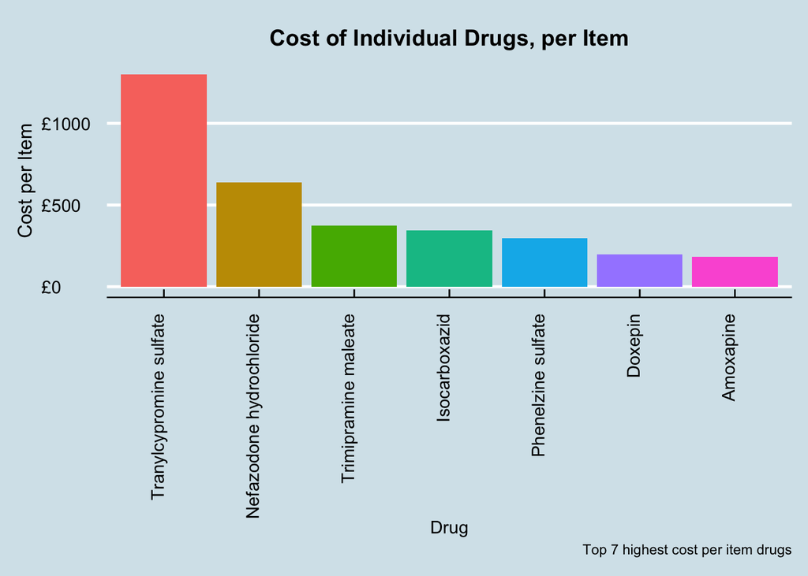

```r
df %>%
  group_by(DRUG) %>%
  summarise(ItemTotal = sum(ITEMS),
            ItemCost = sum(COST),
            CperI = ItemCost/ItemTotal) %>%
  top_n(7, CperI) %>%
  mutate(DRUG = fct_reorder(DRUG, CperI, .desc = TRUE)) %>%
  ggplot(aes(x = DRUG, y = CperI, fill = DRUG)) +
  geom_col() +
  theme_economist() +
  theme(axis.text.x = element_text(angle = 90, hjust = 1)) +
  theme(legend.position = 'none') +
  scale_y_continuous(labels = function(x) paste0("£", x)) +
  labs(y = 'Cost per Item',
       x = 'Drug',
       title = 'Cost of Individual Drugs, per Item',
       caption = 'Top 7 highest cost per item drugs') +
  theme(plot.title = element_text(hjust = 0.5, size = 14, margin = margin(b = 10, t = 5))) +
  theme(axis.title.y = element_text(hjust = 0.5, size = 12, margin = margin(r = 5)))
```

Anything else you think might be informative or relevant (be creative!) Map of regions, point size = total drug for that region. 2024.

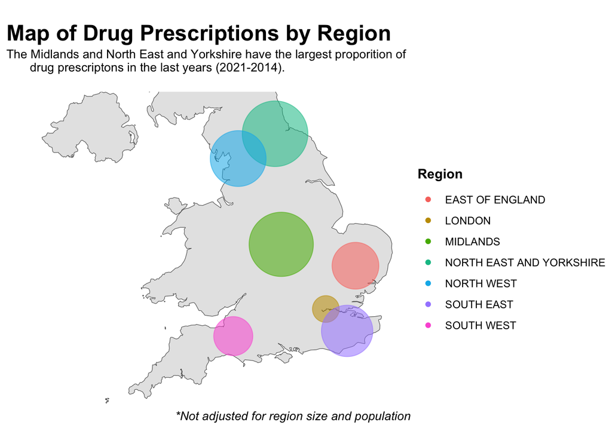

```r
uk <- gb_adm0("GBR")

latitudes <- c(52.252929, 51.5072, 52.621223, 54.526905, 54.099752, 51.129932, 51.039854)
longitudes <- c(0.710673, -0.1276, -1.389856,-1.564316, -2.607994, 0.474771, -2.746780)

drug_map_data <- df %>%
  group_by(REGION) %>%
  summarise(itemTotals = sum(ITEMS)) %>%
  ungroup()

drug_map_data <- cbind(drug_map_data, y_lat = latitudes, x_long = longitudes)

p <- ggplot() +
  geom_sf(data = uk) +
  geom_point(data = drug_map_data, aes(x = x_long, y = y_lat, size = itemTotals, color = REGION, alpha = .3)) +
  scale_size_continuous(range = c(10, 25)) +
  scale_color_discrete(expression(paste(bold(name = 'Region')))) +
  ylim(50, 55) +
  guides(size = 'none', alpha = 'none') +
  theme_void() +
  labs(title = expression(paste(bold('Map of Drug Prescriptions by Region'))),
       caption = expression(paste(italic('*Not adjusted for region size and population'))),
       subtitle = 'The Midlands and North East and Yorkshire have the largest proporition of
       drug prescriptons in the last years (2021-2014).') +
  theme(plot.title = element_text(hjust = 0, size = 18, margin = margin(t = 20))) +
  theme(plot.caption = element_text(hjust = 1, size = 10, margin = margin(b = 10))) +
  theme(plot.subtitle = element_text(hjust = 0, size = 10, margin = margin(b = 15)))

p
```